# Tarification automobile par GLM — BASEAUTO

Modélisation fréquence × coût et grille de prime pure

Auteur·rice

TCHIO CLAVERT

Date de publication

16 octobre 2026

# 1 Partie A — Analyse exploratoire

## 1.1 Importation et visualisation des données

**Afficher le code**

```r
df <- read.csv("BASEAUTO.csv", sep = ";", dec = ".", stringsAsFactors = FALSE)
cat("Dimensions :", nrow(df), "lignes x", ncol(df), "colonnes\n")
```

```
Dimensions : 10496 lignes x 17 colonnes
```

**Afficher le code**

```r
head(df, 6) |>
  kbl_out(caption = "Aperçu des 6 premières observations")
```

Aperçu des 6 premières observations

| PERMIS | ACV | SEX | STATUT | CSP | USAGE | AGECOND | K8000 | RM | CAR | CLA | ALI | ENE | VIT | SEGM | GARAGE | CHARGE |
| --- | --- | --- | --- | --- | --- | --- | --- | --- | --- | --- | --- | --- | --- | --- | --- | --- |
| 245 | 10 | F | C | 50 | 2 | 40 | N | 64 | BER | A | CAR | ES | 130-140 | A | 3 | 0 |
| 348 | 10 | F | A | 50 | 1 | 63 | N | 50 | BER | A | CAR | ES | 001-130 | 0 | 3 | 0 |
| 16 | 10 | F | C | 26 | 2 | 20 | N | 95 | BER | A | CAR | ES | 001-130 | 0 | 3 | 0 |
| 291 | 10 | F | A | 50 | 1 | 56 | N | 50 | BER | A | CAR | ES | 001-130 | 0 | 3 | 0 |
| 123 | 10 | F | A | 50 | 1 | 29 | N | 95 | BER | A | CAR | ES | 140-150 | B | 3 | 0 |
| 295 | 10 | F | A | 37 | 1 | 43 | O | 50 | BER | A | CAR | ES | 001-130 | A | 3 | 0 |

**Afficher le code**

```r
str(df)
```

```
'data.frame':   10496 obs. of  17 variables:
 $ PERMIS : int  245 348 16 291 123 295 24 181 157 338 ...
 $ ACV    : int  10 10 10 10 10 10 10 9 10 10 ...
 $ SEX    : chr  "F" "F" "F" "F" ...
 $ STATUT : chr  "C" "A" "C" "A" ...
 $ CSP    : int  50 50 26 50 50 37 50 50 55 1 ...
 $ USAGE  : int  2 1 2 1 1 1 2 3 1 2 ...
 $ AGECOND: int  40 63 20 56 29 43 21 35 31 48 ...
 $ K8000  : chr  "N" "N" "N" "N" ...
 $ RM     : int  64 50 95 50 95 50 90 50 72 50 ...
 $ CAR    : chr  "BER" "BER" "BER" "BER" ...
 $ CLA    : chr  "A" "A" "A" "A" ...
 $ ALI    : chr  "CAR" "CAR" "CAR" "CAR" ...
 $ ENE    : chr  "ES" "ES" "ES" "ES" ...
 $ VIT    : chr  "130-140" "001-130" "001-130" "001-130" ...
 $ SEGM   : chr  "A" "0" "0" "0" ...
 $ GARAGE : int  3 3 3 3 3 3 3 3 3 2 ...
 $ CHARGE : int  0 0 0 0 0 0 0 0 0 179 ...
```

**Interprétation :** La base BASEAUTO contient **10496 polices** et **17 variables** : caractéristiques du conducteur (âge, sexe, statut, CSP, ancienneté du permis), du véhicule (type, classe SRA, énergie, vitesse, segment) et la variable cible **CHARGE** (montant annuel de remboursement en euros). Le taux de sinistralité est de **13.3%**.

## 1.2 Conversion des types de données

**Afficher le code**

```r
vars_quali <- c("SEX","STATUT","K8000","CAR","CLA","ALI","ENE","VIT","SEGM","USAGE","GARAGE")
for (v in vars_quali) df[[v]] <- as.factor(df[[v]])

# Tableau récapitulatif
data.frame(
  Variable  = vars_quali,
  Modalites = sapply(vars_quali, function(v) nlevels(df[[v]]))
) |> kbl_out(caption = "Nombre de modalités par variable qualitative")
```

Nombre de modalités par variable qualitative

|  | Variable | Modalites |
| --- | --- | --- |
| SEX | SEX | 2 |
| STATUT | STATUT | 2 |
| K8000 | K8000 | 2 |
| CAR | CAR | 9 |
| CLA | CLA | 26 |
| ALI | ALI | 5 |
| ENE | ENE | 3 |
| VIT | VIT | 10 |
| SEGM | SEGM | 6 |
| USAGE | USAGE | 4 |
| GARAGE | GARAGE | 3 |

## 1.3 Statistiques descriptives univariées

### 1.3.1 Variables quantitatives

**Afficher le code**

```r
vars_quanti <- c("PERMIS","ACV","AGECOND","RM","CHARGE")

do.call(rbind, lapply(vars_quanti, function(v) {
  x <- df[[v]]
  data.frame(
    Variable   = v,
    Moyenne    = round(mean(x, na.rm=TRUE), 2),
    Ecart_type = round(sd(x, na.rm=TRUE), 2),
    Min        = round(min(x, na.rm=TRUE), 2),
    Q25        = round(quantile(x, 0.25, na.rm=TRUE), 2),
    Mediane    = round(median(x, na.rm=TRUE), 2),
    Q75        = round(quantile(x, 0.75, na.rm=TRUE), 2),
    Q99        = round(quantile(x, 0.99, na.rm=TRUE), 2),
    Max        = round(max(x, na.rm=TRUE), 2)
  )
})) |> kbl_out(caption = "Statistiques descriptives — variables quantitatives")
```

Statistiques descriptives — variables quantitatives

|  | Variable | Moyenne | Ecart_type | Min | Q25 | Mediane | Q75 | Q99 | Max |
| --- | --- | --- | --- | --- | --- | --- | --- | --- | --- |
| 25% | PERMIS | 298.89 | 162.42 | 1 | 163.75 | 281 | 422 | 689.0 | 940 |
| 25%1 | ACV | 5.96 | 3.56 | 0 | 2.00 | 7 | 10 | 10.0 | 10 |
| 25%2 | AGECOND | 46.75 | 14.76 | 19 | 34.00 | 45 | 57 | 82.0 | 103 |
| 25%3 | RM | 65.82 | 19.36 | 50 | 50.00 | 57 | 80 | 118.0 | 258 |
| 25%4 | CHARGE | 244.02 | 1406.10 | 0 | 0.00 | 0 | 0 | 4395.4 | 67261 |

**Afficher le code**

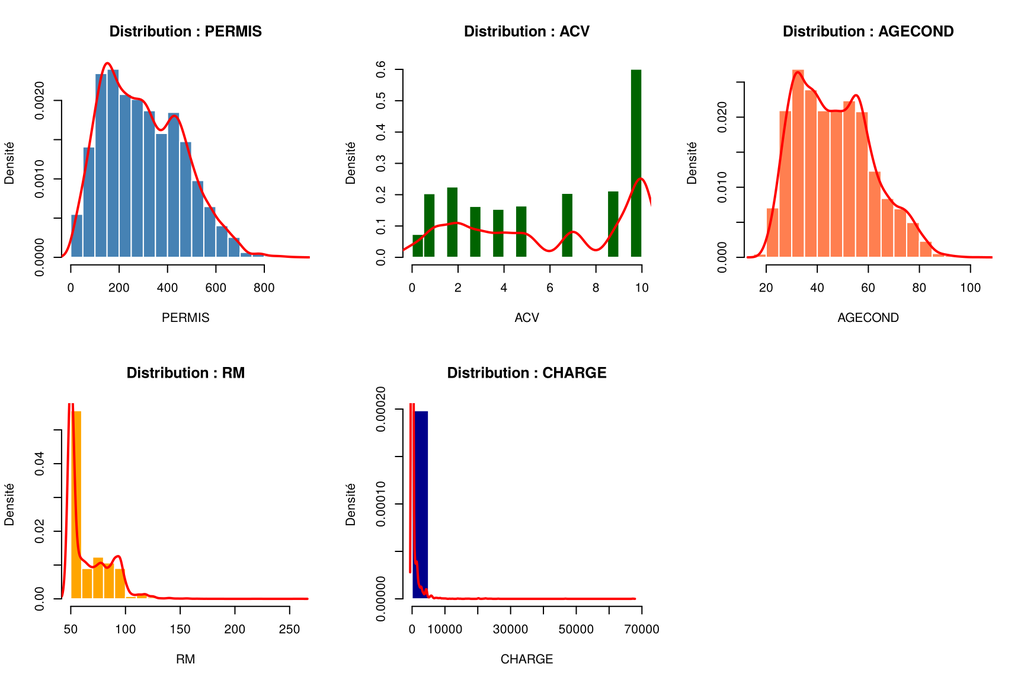

```r
par(mfrow = c(2, 3))
cols <- c("steelblue","darkgreen","coral","orange","darkblue")
for (i in seq_along(vars_quanti)) {
  v <- vars_quanti[i]
  hist(df[[v]], probability = TRUE, col = cols[i], border = "white",
       main = paste("Distribution :", v), xlab = v, ylab = "Densité")
  lines(density(df[[v]], na.rm = TRUE), col = "red", lwd = 2)
}
par(mfrow = c(1, 1))
```

**Interprétation :** La variable **CHARGE** est très asymétrique à droite — 86.7% des polices ont CHARGE = 0 (aucun sinistre sur l’année). Parmi les sinistrés, les montants varient fortement. Le **RM** est concentré entre 50 et 100, témoignant d’un portefeuille globalement bien noté.

### 1.3.2 Variables qualitatives

**Afficher le code**

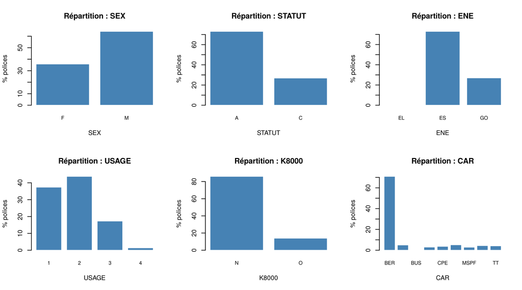

```r
vars_bar <- c("SEX","STATUT","ENE","USAGE","K8000","CAR")
par(mfrow = c(2, 3))
for (v in vars_bar) {
  tab <- round(prop.table(table(df[[v]])) * 100, 1)
  barplot(tab, col = "steelblue", border = "white",
          main = paste("Répartition :", v),
          xlab = v, ylab = "% polices", cex.names = 0.8)
}
```

**Afficher le code**

```r
par(mfrow = c(1, 1))
```

## 1.4 Regroupements de modalités

### 1.4.1 (a) CSP → 3 catégories

**Afficher le code**

```r
# CAT1 : CSP = 50  |  CAT2 : CSP = 55 ou 60  |  CAT3 : autres
df$CSP3 <- case_when(
  df$CSP == 50           ~ "CAT1",
  df$CSP %in% c(55, 60)  ~ "CAT2",
  TRUE                    ~ "CAT3"
)
df$CSP3 <- factor(df$CSP3, levels = c("CAT1","CAT2","CAT3"))
print(table(df$CSP3))
```

```
CAT1 CAT2 CAT3
6051 2240 2205
```

**Afficher le code**

```r
round(prop.table(table(df$CSP3)) * 100, 2)
```

```
 CAT1  CAT2  CAT3
57.65 21.34 21.01
```

### 1.4.2 (b) CLA → Eco / Inter / Cher

**Afficher le code**

```r
# Eco : A-G  |  Inter : H-L  |  Cher : toutes les autres modalités
df$CLA3 <- case_when(
  df$CLA %in% c("A","B","C","D","E","F","G") ~ "Eco",
  df$CLA %in% c("H","I","J","K","L")         ~ "Inter",
  TRUE                                         ~ "Cher"
)
df$CLA3 <- factor(df$CLA3, levels = c("Eco","Inter","Cher"))
print(table(df$CLA3))
```

```
  Eco Inter  Cher
 4051  4114  2331
```

**Afficher le code**

```r
round(prop.table(table(df$CLA3)) * 100, 2)
```

```
  Eco Inter  Cher
38.60 39.20 22.21
```

### 1.4.3 (c) VIT → Lent / VitMoy / Rapide

**Afficher le code**

```r
# VIT est une chaîne de caractères dans BASEAUTO
# Lent : 001-130 à 150-160  |  VitMoy : 160-170 à 180-190  |  Rapide : autres
vit_lent  <- c("001-130","130-140","140-150","150-160")
vit_moyen <- c("160-170","170-180","180-190")

df$VIT3 <- case_when(
  df$VIT %in% vit_lent  ~ "Lent",
  df$VIT %in% vit_moyen ~ "VitMoy",
  TRUE                   ~ "Rapide"
)
df$VIT3 <- factor(df$VIT3, levels = c("Lent","VitMoy","Rapide"))
print(table(df$VIT3))
```

```
  Lent VitMoy Rapide
  3101   4807   2588
```

**Afficher le code**

```r
round(prop.table(table(df$VIT3)) * 100, 2)
```

```
  Lent VitMoy Rapide
 29.54  45.80  24.66
```

### 1.4.4 (d) CAR → Luxe / Commun / Familial

**Afficher le code**

```r
# Luxe : BER, CAB, CPE  |  Commun : CTE, BUS, TT  |  Familial : autres
df$CAR3 <- case_when(
  df$CAR %in% c("BER","CAB","CPE") ~ "Luxe",
  df$CAR %in% c("CTE","BUS","TT")  ~ "Commun",
  TRUE                               ~ "Familial"
)
df$CAR3 <- factor(df$CAR3, levels = c("Luxe","Commun","Familial"))
print(table(df$CAR3))
```

```
    Luxe   Commun Familial
    8161     1042     1293
```

**Afficher le code**

```r
round(prop.table(table(df$CAR3)) * 100, 2)
```

```
    Luxe   Commun Familial
   77.75     9.93    12.32
```

**Afficher le code**

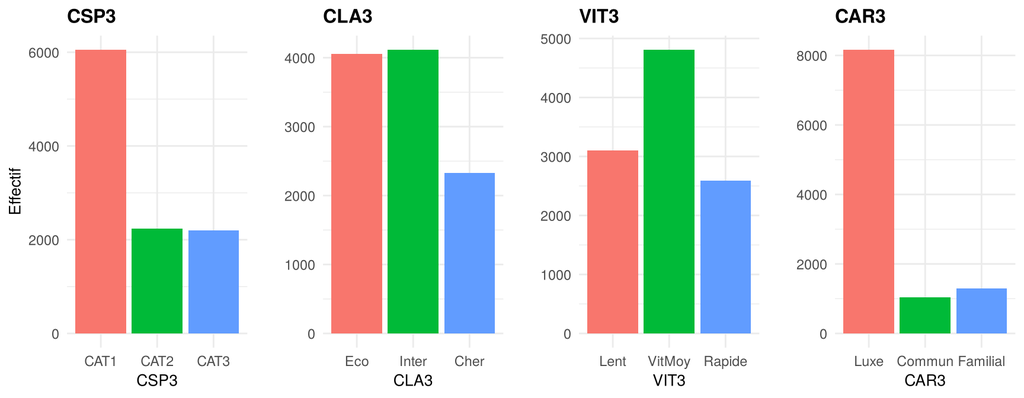

```r
g1 <- ggplot(df, aes(x=CSP3, fill=CSP3)) + geom_bar() +
      labs(title="CSP3", y="Effectif") + theme(legend.position="none")
g2 <- ggplot(df, aes(x=CLA3, fill=CLA3)) + geom_bar() +
      labs(title="CLA3", y="") + theme(legend.position="none")
g3 <- ggplot(df, aes(x=VIT3, fill=VIT3)) + geom_bar() +
      labs(title="VIT3", y="") + theme(legend.position="none")
g4 <- ggplot(df, aes(x=CAR3, fill=CAR3)) + geom_bar() +
      labs(title="CAR3", y="") + theme(legend.position="none")
grid.arrange(g1, g2, g3, g4, ncol=4)
```

## 1.5 Statistiques descriptives bivariées

**Afficher le code**

```r
vars_biv <- c("CSP3","CLA3","VIT3","CAR3","SEX","STATUT","ENE","USAGE")

res_biv <- do.call(rbind, lapply(vars_biv, function(v) {
  df |> group_by(Modalite = .data[[v]]) |>
    summarise(N = n(),
              Charge_moy    = round(mean(CHARGE, na.rm=TRUE), 2),
              Freq_sin_pct  = round(mean(CHARGE > 0)*100, 2),
              .groups = "drop") |>
    mutate(Variable = v, .before = 1)
}))

res_biv |> kbl_out(caption = "Charge moyenne et fréquence de sinistre par variable")
```

Charge moyenne et fréquence de sinistre par variable

| Variable | Modalite | N | Charge_moy | Freq_sin_pct |
| --- | --- | --- | --- | --- |
| CSP3 | CAT1 | 6051 | 231.48 | 12.49 |
| CSP3 | CAT2 | 2240 | 224.04 | 14.29 |
| CSP3 | CAT3 | 2205 | 298.71 | 14.60 |
| CLA3 | Eco | 4051 | 175.09 | 9.68 |
| CLA3 | Inter | 4114 | 265.56 | 14.75 |
| CLA3 | Cher | 2331 | 325.77 | 17.12 |
| VIT3 | Lent | 3101 | 143.53 | 8.74 |
| VIT3 | VitMoy | 4807 | 256.97 | 14.00 |
| VIT3 | Rapide | 2588 | 340.36 | 17.54 |
| CAR3 | Luxe | 8161 | 226.62 | 12.77 |
| CAR3 | Commun | 1042 | 328.44 | 14.49 |
| CAR3 | Familial | 1293 | 285.79 | 15.85 |
| SEX | F | 3761 | 249.79 | 13.61 |
| SEX | M | 6735 | 240.79 | 13.16 |
| STATUT | A | 7668 | 257.21 | 13.91 |
| STATUT | C | 2828 | 208.25 | 11.70 |
| ENE | EL | 2 | 1392.50 | 50.00 |
| ENE | ES | 7665 | 211.73 | 12.29 |
| ENE | GO | 2829 | 330.67 | 16.08 |
| USAGE | 1 | 3929 | 183.78 | 10.89 |
| USAGE | 2 | 4600 | 240.29 | 12.74 |
| USAGE | 3 | 1819 | 365.25 | 19.19 |
| USAGE | 4 | 148 | 468.82 | 23.65 |

**Afficher le code**

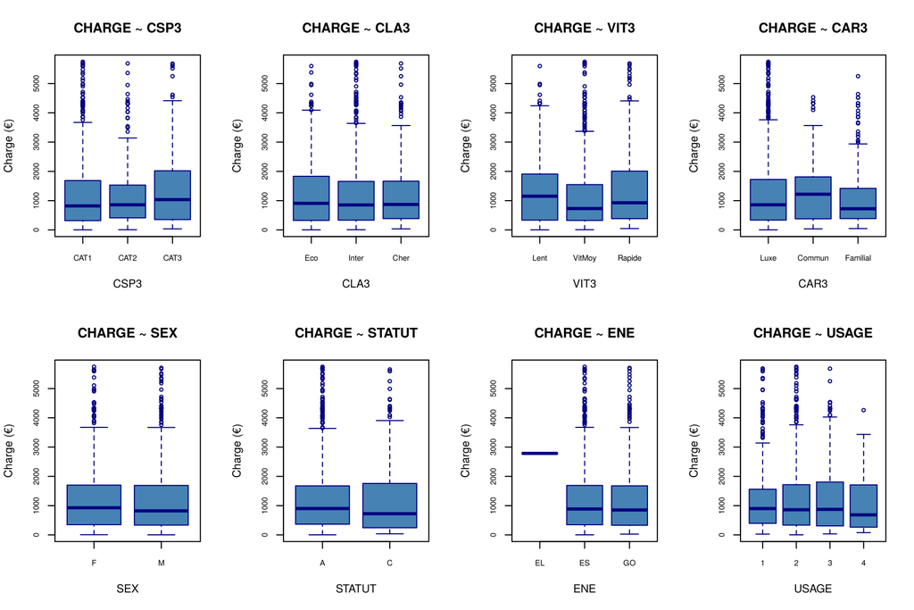

```r
# Zoomer sur les sinistrés (hors extrêmes) pour la lisibilité
df_bv <- df[df$CHARGE > 0 & df$CHARGE < quantile(df$CHARGE[df$CHARGE>0], 0.95), ]
par(mfrow = c(2, 4))
for (v in vars_biv) {
  boxplot(df_bv$CHARGE ~ df_bv[[v]],
          col="steelblue", border="navy", main=paste("CHARGE ~", v),
          xlab=v, ylab="Charge (€)", cex.axis=0.7)
}
```

**Afficher le code**

```r
par(mfrow = c(1, 1))
```

**Afficher le code**

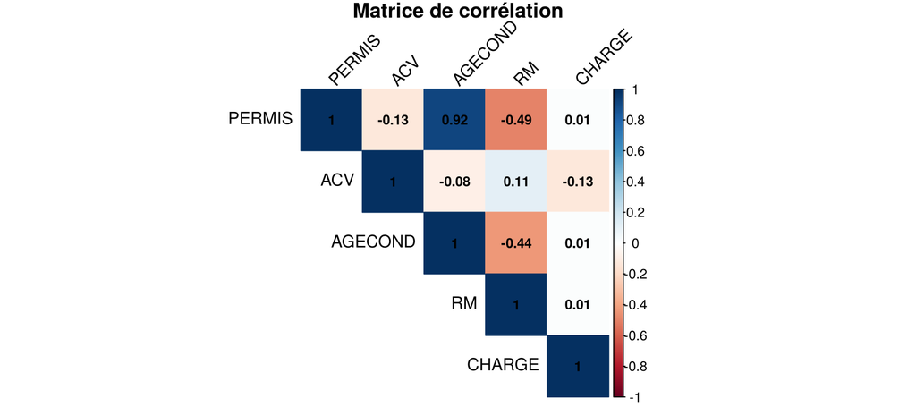

```r
mat_cor <- cor(df[, c("PERMIS","ACV","AGECOND","RM","CHARGE")], use="complete.obs")
corrplot(mat_cor, method="color", type="upper", addCoef.col="black",
         number.cex=0.8, tl.col="black", tl.srt=45,
         title="Matrice de corrélation", mar=c(0,0,1,0))
```

## 1.6 À quoi servent les analyses préliminaires ?

| Type | Utilité |
| --- | --- |
| **Univariée** | Comprendre la distribution, détecter les valeurs aberrantes, identifier les modalités rares à regrouper |
| **Bivariée** | Mesurer l’effet brut de chaque variable sur la charge → discrimination tarifaire |
| **Corrélation** | Détecter la multicolinéarité → risque d’instabilité du GLM |
| **Stabilité temporelle** | Vérifier que le portefeuille n’a pas dérivé dans le temps → stationnarité nécessaire |

# 2 Partie B — Préparation à la modélisation

## 2.1 Profil de référence

**Afficher le code**

```r
vars_pr <- c("SEX","STATUT","USAGE","CAR3","CLA3","VIT3","ENE","K8000","GARAGE","CSP3")
profil <- data.frame(
  Variable  = vars_pr,
  Reference = sapply(vars_pr, function(v) names(which.max(table(df[[v]])))),
  Effectif  = sapply(vars_pr, function(v) max(table(df[[v]])))
)
profil$Pct <- round(profil$Effectif / nrow(df) * 100, 1)

profil |> kbl_out(caption = "Profil de référence du portefeuille")
```

Profil de référence du portefeuille

|  | Variable | Reference | Effectif | Pct |
| --- | --- | --- | --- | --- |
| SEX | SEX | M | 6735 | 64.2 |
| STATUT | STATUT | A | 7668 | 73.1 |
| USAGE | USAGE | 2 | 4600 | 43.8 |
| CAR3 | CAR3 | Luxe | 8161 | 77.8 |
| CLA3 | CLA3 | Inter | 4114 | 39.2 |
| VIT3 | VIT3 | VitMoy | 4807 | 45.8 |
| ENE | ENE | ES | 7665 | 73.0 |
| K8000 | K8000 | N | 9023 | 86.0 |
| GARAGE | GARAGE | 3 | 7602 | 72.4 |
| CSP3 | CSP3 | CAT1 | 6051 | 57.7 |

**Le profil de référence** correspond à l’assuré le plus représentatif du portefeuille : conducteur **M**, statut **A**, usage **2**, véhicule **Luxe**, classe SRA **Inter**, vitesse **VitMoy**, énergie **ES**.

## 2.2 Séparation sinistres attritionnels / graves

**Afficher le code**

```r
# Base des sinistrés uniquement
df_sin <- subset(df, CHARGE > 0)
cat("Nombre total de sinistrés :", nrow(df_sin), "\n")
```

```
Nombre total de sinistrés : 1398
```

**Afficher le code**

```r
# Seuil : percentile 99 de la charge conditionnelle
limite <- quantile(df_sin$CHARGE, 0.99)
cat("Seuil Q99 :", round(limite, 2), "euros\n")
```

```
Seuil Q99 : 17490.47 euros
```

**Afficher le code**

```r
df_attri  <- df_sin[df_sin$CHARGE <= limite, ]
df_graves <- df_sin[df_sin$CHARGE >  limite, ]

rbind(
  data.frame(Base="Attritionnels", N=nrow(df_attri),
             Min=round(min(df_attri$CHARGE),0),
             Moy=round(mean(df_attri$CHARGE),0),
             Max=round(max(df_attri$CHARGE),0)),
  data.frame(Base="Graves", N=nrow(df_graves),
             Min=round(min(df_graves$CHARGE),0),
             Moy=round(mean(df_graves$CHARGE),0),
             Max=round(max(df_graves$CHARGE),0))
) |> kbl_out(caption = "Caractéristiques des deux bases")
```

Caractéristiques des deux bases

| Base | N | Min | Moy | Max |
| --- | --- | --- | --- | --- |
| Attritionnels | 1384 | 3 | 1576 | 17408 |
| Graves | 14 | 20157 | 27159 | 67261 |

**Afficher le code**

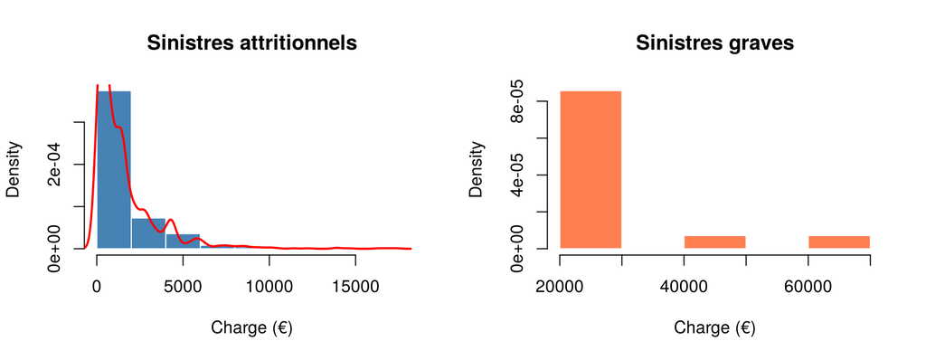

```r
par(mfrow = c(1, 2))
hist(df_attri$CHARGE,  col="steelblue", border="white", probability=TRUE,
     main="Sinistres attritionnels", xlab="Charge (€)")
lines(density(df_attri$CHARGE), col="red", lwd=2)
hist(df_graves$CHARGE, col="coral",     border="white", probability=TRUE,
     main="Sinistres graves", xlab="Charge (€)")
```

**Afficher le code**

```r
par(mfrow = c(1, 1))
```

## 2.3 Base de construction du tarif

Le tarif est construit sur la **base attritionnelle** (1384 sinistres). Les sinistres graves sont traités via un **chargement additionnel** ou la **réassurance**.

## 2.4 Échantillons apprentissage / test

**Afficher le code**

```r
set.seed(2025)
n      <- nrow(df_attri)
idx_tr <- sample(seq_len(n), size = round(0.80 * n))
train  <- df_attri[ idx_tr, ]
test   <- df_attri[-idx_tr, ]

cat("Apprentissage :", nrow(train), "obs. (80%) | Test :", nrow(test), "obs. (20%)\n")
```

```
Apprentissage : 1107 obs. (80%) | Test : 277 obs. (20%)
```

## 2.5 Tests d’adéquation de la charge

**Afficher le code**

```r
# -- Base : tous les sinistres attritionnels (> 0, <= seuil Q99) --------------
charge_pos <- df_attri$CHARGE[df_attri$CHARGE > 0]
n_cp       <- length(charge_pos)
cat("N observations :", n_cp, "| Min :", round(min(charge_pos), 2),
    "| Max :", round(max(charge_pos), 2), "\n")
```

```
N observations : 1384 | Min : 3 | Max : 17408
```

**Afficher le code**

```r
# -- Estimation par maximum de vraisemblance pour les trois lois --------------
# Les montants sont mis à l'échelle (k€) pour stabiliser l'optimisation,
# puis la log-vraisemblance est corrigée du jacobien du changement d'échelle.
ech <- 1000
xs  <- charge_pos / ech

fit_g <- fitdistr(xs, "gamma")
fit_l <- fitdistr(charge_pos, "lognormal")
fit_w <- fitdistr(xs, "weibull")

shape_g <- unname(fit_g$estimate["shape"])
rate_g  <- unname(fit_g$estimate["rate"]) / ech
meanlog <- unname(fit_l$estimate["meanlog"])
sdlog   <- unname(fit_l$estimate["sdlog"])
shape_w <- unname(fit_w$estimate["shape"])
scale_w <- unname(fit_w$estimate["scale"]) * ech

ll <- c(
  Gamma         = sum(dgamma(charge_pos, shape = shape_g, rate = rate_g, log = TRUE)),
  `Log-normale` = sum(dlnorm(charge_pos, meanlog = meanlog, sdlog = sdlog, log = TRUE)),
  Weibull       = sum(dweibull(charge_pos, shape = shape_w, scale = scale_w, log = TRUE))
)
k <- 2  # deux paramètres pour chaque loi

comp <- data.frame(
  Loi      = names(ll),
  LogVrais = round(ll, 2),
  AIC      = round(-2 * ll + 2 * k, 2),
  BIC      = round(-2 * ll + k * log(n_cp), 2),
  row.names = NULL
)
comp$Meilleure <- ifelse(comp$AIC == min(comp$AIC), "✓", "")
comp |> kbl_out(caption = "Comparaison des lois (maximum de vraisemblance) — AIC, BIC")
```

Comparaison des lois (maximum de vraisemblance) — AIC, BIC

| Loi | LogVrais | AIC | BIC | Meilleure |
| --- | --- | --- | --- | --- |
| Gamma | -11566.62 | 23137.24 | 23147.70 |  |
| Log-normale | -11549.54 | 23103.08 | 23113.55 | ✓ |
| Weibull | -11558.32 | 23120.65 | 23131.11 |  |

**Afficher le code**

```r
loi_aic <- comp$Loi[which.min(comp$AIC)]
ecart_aic_gamma <- round(comp$AIC[comp$Loi == "Gamma"] - min(comp$AIC), 1)
```

**Afficher le code**

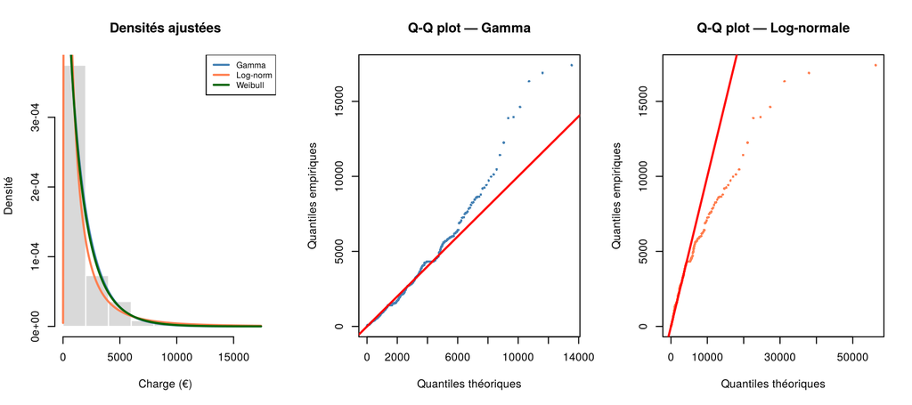

```r
par(mfrow = c(1, 3))
x_seq <- seq(min(charge_pos), max(charge_pos), length.out = 300)

# 1. Densité empirique vs densités ajustées
hist(charge_pos, probability = TRUE, col = "grey85", border = "white",
     main = "Densités ajustées", xlab = "Charge (€)", ylab = "Densité")
lines(x_seq, dgamma(x_seq, shape = shape_g, rate = rate_g),       col = "steelblue", lwd = 2)
lines(x_seq, dlnorm(x_seq, meanlog = meanlog, sdlog = sdlog),     col = "coral",     lwd = 2)
lines(x_seq, dweibull(x_seq, shape = shape_w, scale = scale_w),   col = "darkgreen", lwd = 2)
legend("topright", legend = c("Gamma","Log-norm","Weibull"),
       col = c("steelblue","coral","darkgreen"), lwd = 2, cex = 0.75)

# 2. Q-Q plots Gamma et log-normale
pp <- ppoints(n_cp); q_emp <- sort(charge_pos)
plot(qgamma(pp, shape = shape_g, rate = rate_g), q_emp, pch = 16, cex = 0.5,
     col = "steelblue", main = "Q-Q plot — Gamma",
     xlab = "Quantiles théoriques", ylab = "Quantiles empiriques")
abline(0, 1, col = "red", lwd = 2)
plot(qlnorm(pp, meanlog = meanlog, sdlog = sdlog), q_emp, pch = 16, cex = 0.5,
     col = "coral", main = "Q-Q plot — Log-normale",
     xlab = "Quantiles théoriques", ylab = "Quantiles empiriques")
abline(0, 1, col = "red", lwd = 2)
```

**Afficher le code**

```r
par(mfrow = c(1, 1))
```

**Afficher le code**

```r
# -- Test de Kolmogorov-Smirnov -----------------------------------------------
# Les paramètres étant estimés sur les mêmes données, les p-values du test KS
# classique sont optimistes (problème de Lilliefors) : on les complète par un
# bootstrap paramétrique (B = 200) qui ré-estime les paramètres à chaque tirage.
set.seed(2025)
B <- 200
ks_boot <- function(rgen, refit, pfun, d_obs) {
  d_b <- replicate(B, {
    xb <- rgen(n_cp)
    th <- refit(xb)
    suppressWarnings(ks.test(xb, pfun, th[1], th[2])$statistic)
  })
  mean(d_b >= d_obs)
}

d_g <- suppressWarnings(ks.test(charge_pos, "pgamma", shape_g, rate_g))
d_l <- suppressWarnings(ks.test(charge_pos, "plnorm", meanlog, sdlog))

p_boot_g <- ks_boot(function(n) rgamma(n, shape_g, rate_g),
                    function(x) { f <- fitdistr(x / ech, "gamma")$estimate
                                  c(f[1], f[2] / ech) },
                    "pgamma", d_g$statistic)
p_boot_l <- ks_boot(function(n) rlnorm(n, meanlog, sdlog),
                    function(x) c(mean(log(x)), sqrt(mean((log(x) - mean(log(x)))^2))),
                    "plnorm", d_l$statistic)

data.frame(
  Loi            = c("Gamma", "Log-normale"),
  Statistique_D  = round(c(d_g$statistic, d_l$statistic), 4),
  p_KS_classique = round(c(d_g$p.value, d_l$p.value), 4),
  p_bootstrap    = round(c(p_boot_g, p_boot_l), 3)
) |> kbl_out(caption = "Tests de Kolmogorov-Smirnov (classique et bootstrap paramétrique)")
```

Tests de Kolmogorov-Smirnov (classique et bootstrap paramétrique)

| Loi | Statistique_D | p_KS_classique | p_bootstrap |
| --- | --- | --- | --- |
| Gamma | 0.0652 | 0 | 0 |
| Log-normale | 0.0716 | 0 | 0 |

**Interprétation :** Au sens de l’AIC, la meilleure loi est la **Log-normale** (écart d’AIC avec la Gamma : 34.2 points). Pour le GLM coût, on retient néanmoins la **famille Gamma avec lien log** : elle modélise directement l’espérance du coût (sans biais de retransformation, contrairement à une régression sur log(CHARGE)), donne des effets multiplicatifs lisibles et constitue le standard de la tarification non-vie. Une régression log-normale pourrait être testée en variante.

Le test KS (p-value bootstrap : 0 pour la Gamma, 0 pour la log-normale) rejette les deux lois au seuil de 5 % : avec plus de 1 300 observations, le test détecte des écarts même modérés, visibles sur les Q-Q plots dans la queue droite. Aucune loi paramétrique simple ne décrit parfaitement la charge ; la Gamma est utilisée ici comme hypothèse de travail pour le GLM, ce qui est une limite à garder en tête.

# 3 Partie C — Modélisation GLM

## 3.1 GLM Fréquence — Loi Binomiale / Lien logit

**Afficher le code**

```r
# Base complète (sinistrés + non sinistrés) avec l'indicateur binaire
df_freq <- df
df_freq$indicateur <- as.integer(df_freq$CHARGE > 0)
cat("Taux de sinistralité :", round(mean(df_freq$indicateur)*100, 2), "%\n")
```

```
Taux de sinistralité : 13.32 %
```

**Afficher le code**

```r
# Profil de référence → modalités les plus fréquentes
df_freq$SEX    <- relevel(as.factor(df_freq$SEX),    ref = "M")
df_freq$STATUT <- relevel(as.factor(df_freq$STATUT), ref = "A")
df_freq$USAGE  <- relevel(as.factor(df_freq$USAGE),  ref = "2")
df_freq$K8000  <- relevel(as.factor(df_freq$K8000),  ref = "N")
df_freq$ENE    <- relevel(as.factor(df_freq$ENE),    ref = "ES")
df_freq$GARAGE <- relevel(as.factor(df_freq$GARAGE), ref = "3")
df_freq$CSP3   <- relevel(as.factor(df_freq$CSP3),   ref = "CAT1")
df_freq$CLA3   <- relevel(as.factor(df_freq$CLA3),   ref = "Inter")
df_freq$VIT3   <- relevel(as.factor(df_freq$VIT3),   ref = "VitMoy")
df_freq$CAR3   <- relevel(as.factor(df_freq$CAR3),   ref = "Luxe")

# Split 80/20
set.seed(2025)
idx_f   <- sample(seq_len(nrow(df_freq)), round(0.8 * nrow(df_freq)))
train_f <- df_freq[ idx_f, ]
test_f  <- df_freq[-idx_f, ]
```

**Afficher le code**

```r
formule_freq <- indicateur ~ CSP3 + CLA3 + VIT3 + CAR3 +
                SEX + STATUT + USAGE + K8000 + ENE + GARAGE +
                RM + AGECOND + PERMIS + ACV

mod_freq <- glm(formule_freq, family = binomial(link = "logit"),
                data = train_f, na.action = na.omit)
summary(mod_freq)
```

```
Call:
glm(formula = formule_freq, family = binomial(link = "logit"),
    data = train_f, na.action = na.omit)

Coefficients:
               Estimate Std. Error z value Pr(>|z|)
(Intercept)  -0.9731301  0.2519731  -3.862 0.000112 ***
CSP3CAT2      0.1149668  0.0996849   1.153 0.248786
CSP3CAT3     -0.0257251  0.0895963  -0.287 0.774019
CLA3Eco      -0.1344530  0.0998455  -1.347 0.178106
CLA3Cher      0.1960901  0.0984201   1.992 0.046329 *
VIT3Lent     -0.1630715  0.1009676  -1.615 0.106292
VIT3Rapide   -0.0290369  0.0958662  -0.303 0.761974
CAR3Commun   -0.1365380  0.1284981  -1.063 0.287978
CAR3Familial -0.1386715  0.1060674  -1.307 0.191080
SEXF          0.2180716  0.0740779   2.944 0.003242 **
STATUTC       0.0670088  0.0873230   0.767 0.442863
USAGE1       -0.1933125  0.0886707  -2.180 0.029249 *
USAGE3        0.1167930  0.0957193   1.220 0.222404
USAGE4        0.1582772  0.2472160   0.640 0.522018
K8000O       -0.5059800  0.1315542  -3.846 0.000120 ***
ENEEL         2.1128401  1.4200843   1.488 0.136796
ENEGO         0.0324956  0.0803708   0.404 0.685977
GARAGE1      -0.0324883  0.1101530  -0.295 0.768041
GARAGE2      -0.0041644  0.0903080  -0.046 0.963220
RM            0.0029233  0.0019971   1.464 0.143253
AGECOND      -0.0068252  0.0066382  -1.028 0.303870
PERMIS        0.0011496  0.0005844   1.967 0.049186 *
ACV          -0.2173764  0.0112651 -19.296  < 2e-16 ***
---
Signif. codes:  0 '***' 0.001 '**' 0.01 '*' 0.05 '.' 0.1 ' ' 1

(Dispersion parameter for binomial family taken to be 1)

    Null deviance: 6633.4  on 8396  degrees of freedom
Residual deviance: 5963.6  on 8374  degrees of freedom
AIC: 6009.6

Number of Fisher Scoring iterations: 5
```

**Afficher le code**

```r
# Sélection pas-à-pas par AIC
mod_freq_opt <- stepAIC(mod_freq, direction = "both", trace = FALSE)
cat("=== GLM Fréquence optimisé ===\n")
```

```
=== GLM Fréquence optimisé ===
```

**Afficher le code**

```r
summary(mod_freq_opt)
```

```
Call:
glm(formula = indicateur ~ CLA3 + VIT3 + SEX + USAGE + K8000 +
    RM + PERMIS + ACV, family = binomial(link = "logit"), data = train_f,
    na.action = na.omit)

Coefficients:
              Estimate Std. Error z value Pr(>|z|)
(Intercept) -1.1606128  0.1917436  -6.053 1.42e-09 ***
CLA3Eco     -0.0918425  0.0920087  -0.998 0.318185
CLA3Cher     0.1413242  0.0901885   1.567 0.117118
VIT3Lent    -0.1868973  0.0967534  -1.932 0.053398 .
VIT3Rapide   0.0151370  0.0876229   0.173 0.862846
SEXF         0.2183210  0.0731376   2.985 0.002835 **
USAGE1      -0.1939700  0.0844788  -2.296 0.021671 *
USAGE3       0.0710572  0.0894193   0.795 0.426816
USAGE4       0.1104193  0.2417598   0.457 0.647864
K8000O      -0.5073327  0.1310739  -3.871 0.000109 ***
RM           0.0032482  0.0019704   1.648 0.099261 .
PERMIS       0.0006665  0.0002503   2.663 0.007743 **
ACV         -0.2162947  0.0110307 -19.608  < 2e-16 ***
---
Signif. codes:  0 '***' 0.001 '**' 0.01 '*' 0.05 '.' 0.1 ' ' 1

(Dispersion parameter for binomial family taken to be 1)

    Null deviance: 6633.4  on 8396  degrees of freedom
Residual deviance: 5971.5  on 8384  degrees of freedom
AIC: 5997.5

Number of Fisher Scoring iterations: 5
```

**Afficher le code**

```r
anova(mod_freq_opt, test = "Chisq") |> as.data.frame() |> round(4) |>
  kbl_out(caption = "Analyse de la déviance — GLM Fréquence")
```

Analyse de la déviance — GLM Fréquence

|  | Df | Deviance | Resid. Df | Resid. Dev | Pr(>Chi) |
| --- | --- | --- | --- | --- | --- |
| NULL | NA | NA | 8396 | 6633.397 | NA |
| CLA3 | 2 | 65.0096 | 8394 | 6568.388 | 0.0000 |
| VIT3 | 2 | 29.1004 | 8392 | 6539.287 | 0.0000 |
| SEX | 1 | 13.1839 | 8391 | 6526.103 | 0.0003 |
| USAGE | 3 | 57.2126 | 8388 | 6468.891 | 0.0000 |
| K8000 | 1 | 38.5800 | 8387 | 6430.311 | 0.0000 |
| RM | 1 | 1.3881 | 8386 | 6428.923 | 0.2387 |
| PERMIS | 1 | 17.4532 | 8385 | 6411.469 | 0.0000 |
| ACV | 1 | 439.9287 | 8384 | 5971.541 | 0.0000 |

**Afficher le code**

```r
ic_freq <- confint(mod_freq_opt, level = 0.95)
data.frame(
  Coeff    = round(coef(mod_freq_opt), 4),
  OR       = round(exp(coef(mod_freq_opt)), 4),
  IC_inf   = round(exp(ic_freq[,1]), 4),
  IC_sup   = round(exp(ic_freq[,2]), 4)
) |> kbl_out(caption = "Odds-Ratios et IC 95% — GLM Fréquence")
```

Odds-Ratios et IC 95% — GLM Fréquence

|  | Coeff | OR | IC_inf | IC_sup |
| --- | --- | --- | --- | --- |
| (Intercept) | -1.1606 | 0.3133 | 0.2154 | 0.4567 |
| CLA3Eco | -0.0918 | 0.9122 | 0.7613 | 1.0921 |
| CLA3Cher | 0.1413 | 1.1518 | 0.9647 | 1.3740 |
| VIT3Lent | -0.1869 | 0.8295 | 0.6855 | 1.0018 |
| VIT3Rapide | 0.0151 | 1.0153 | 0.8547 | 1.2051 |
| SEXF | 0.2183 | 1.2440 | 1.0775 | 1.4353 |
| USAGE1 | -0.1940 | 0.8237 | 0.6976 | 0.9715 |
| USAGE3 | 0.0711 | 1.0736 | 0.9003 | 1.2784 |
| USAGE4 | 0.1104 | 1.1167 | 0.6829 | 1.7682 |
| K8000O | -0.5073 | 0.6021 | 0.4626 | 0.7738 |
| RM | 0.0032 | 1.0033 | 0.9993 | 1.0071 |
| PERMIS | 0.0007 | 1.0007 | 1.0002 | 1.0012 |
| ACV | -0.2163 | 0.8055 | 0.7881 | 0.8230 |

**Afficher le code**

```r
pred_f <- predict(mod_freq_opt, newdata = test_f, type = "response")
cat("Fréquence prédite :", round(mean(pred_f), 4), "\n")
```

```
Fréquence prédite : 0.1336
```

**Afficher le code**

```r
cat("Fréquence observée:", round(mean(test_f$indicateur), 4), "\n")
```

```
Fréquence observée: 0.1277
```

**Afficher le code**

```r
cat("Écart relatif     :",
    round(abs(mean(pred_f)-mean(test_f$indicateur))/mean(test_f$indicateur)*100, 2), "%\n")
```

```
Écart relatif     : 4.61 %
```

**Afficher le code**

```r
# -- Pouvoir discriminant sur l'échantillon test : AUC, Gini, courbe de Lorenz -
auc_fun <- function(y, p) {
  r <- rank(p); n1 <- sum(y == 1); n0 <- sum(y == 0)
  (sum(r[y == 1]) - n1 * (n1 + 1) / 2) / (n1 * n0)
}
auc_f  <- auc_fun(test_f$indicateur, pred_f)
gini_f <- 2 * auc_f - 1
cat("AUC (test)  :", round(auc_f, 3), "\n")
```

```
AUC (test)  : 0.732
```

**Afficher le code**

```r
cat("Gini (test) :", round(gini_f, 3), "\n")
```

```
Gini (test) : 0.464
```

**Afficher le code**

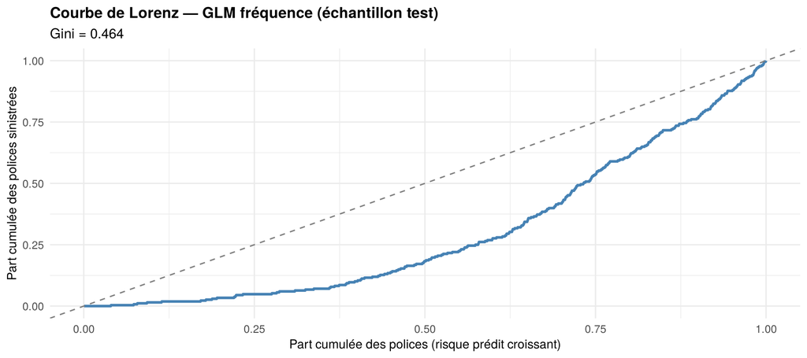

```r
# Courbe de Lorenz ordonnée : polices triées du risque prédit le plus faible au plus fort
o   <- order(pred_f)
lor <- data.frame(part_polices   = seq_along(o) / length(o),
                  part_sinistres = cumsum(test_f$indicateur[o]) / sum(test_f$indicateur))
ggplot(lor, aes(part_polices, part_sinistres)) +
  geom_line(colour = "steelblue", linewidth = 1) +
  geom_abline(linetype = "dashed", colour = "grey50") +
  labs(title = "Courbe de Lorenz — GLM fréquence (échantillon test)",
       subtitle = paste0("Gini = ", round(gini_f, 3)),
       x = "Part cumulée des polices (risque prédit croissant)",
       y = "Part cumulée des polices sinistrées")
```

**Interprétation :** Les odds-ratios > 1 indiquent une hausse de la probabilité de sinistre par rapport au profil de référence. Les variables retenues par stepAIC sont celles qui améliorent le critère AIC ; leur apport individuel se lit dans le tableau d’analyse de la déviance. Sur l’échantillon test, le modèle atteint un Gini de 0.46 : il classe correctement les polices par niveau de risque.

## 3.2 GLM Coût — Loi Gamma / Lien log

**Afficher le code**

```r
# Base attritionnelle — apprentissage
train_c <- train

train_c$SEX    <- relevel(as.factor(train_c$SEX),    ref = "M")
train_c$STATUT <- relevel(as.factor(train_c$STATUT), ref = "A")
train_c$USAGE  <- relevel(as.factor(train_c$USAGE),  ref = "2")
train_c$K8000  <- relevel(as.factor(train_c$K8000),  ref = "N")
train_c$ENE    <- relevel(as.factor(train_c$ENE),    ref = "ES")
train_c$GARAGE <- relevel(as.factor(train_c$GARAGE), ref = "3")
train_c$CSP3   <- relevel(as.factor(train_c$CSP3),   ref = "CAT1")
train_c$CLA3   <- relevel(as.factor(train_c$CLA3),   ref = "Inter")
train_c$VIT3   <- relevel(as.factor(train_c$VIT3),   ref = "VitMoy")
train_c$CAR3   <- relevel(as.factor(train_c$CAR3),   ref = "Luxe")

cat("Base coût apprentissage :", nrow(train_c), "obs.\n")
```

```
Base coût apprentissage : 1107 obs.
```

**Afficher le code**

```r
formule_cout <- CHARGE ~ CSP3 + CLA3 + VIT3 + CAR3 +
                SEX + STATUT + USAGE + K8000 + ENE + GARAGE +
                RM + AGECOND + PERMIS + ACV

mod_cout <- glm(formule_cout, family = Gamma(link = "log"),
                data = train_c, na.action = na.omit)
summary(mod_cout)
```

```
Call:
glm(formula = formule_cout, family = Gamma(link = "log"), data = train_c,
    na.action = na.omit)

Coefficients:
               Estimate Std. Error t value Pr(>|t|)
(Intercept)   6.5564976  0.2745513  23.881  < 2e-16 ***
CSP3CAT2     -0.0452568  0.1146968  -0.395   0.6932
CSP3CAT3      0.1036434  0.0976896   1.061   0.2890
CLA3Eco      -0.1350167  0.1099725  -1.228   0.2198
CLA3Cher     -0.0285720  0.1095909  -0.261   0.7944
VIT3Lent      0.0987361  0.1099422   0.898   0.3693
VIT3Rapide    0.1737358  0.1048496   1.657   0.0978 .
CAR3Commun    0.0175588  0.1400326   0.125   0.9002
CAR3Familial  0.0846203  0.1181365   0.716   0.4740
SEXF          0.0395808  0.0817596   0.484   0.6284
STATUTC      -0.1668483  0.0999016  -1.670   0.0952 .
USAGE1       -0.0184193  0.1038227  -0.177   0.8592
USAGE3       -0.0553389  0.1050375  -0.527   0.5984
USAGE4        0.0454650  0.2460850   0.185   0.8535
K8000O        0.1165896  0.1578941   0.738   0.4604
ENEEL         0.7339042  1.2345459   0.594   0.5523
ENEGO         0.1224308  0.0888373   1.378   0.1684
GARAGE1       0.0422757  0.1266836   0.334   0.7387
GARAGE2      -0.0528169  0.0988506  -0.534   0.5932
RM            0.0083474  0.0020338   4.104 4.36e-05 ***
AGECOND       0.0048295  0.0075607   0.639   0.5231
PERMIS       -0.0001055  0.0006569  -0.161   0.8724
ACV          -0.0006476  0.0144075  -0.045   0.9642
---
Signif. codes:  0 '***' 0.001 '**' 0.01 '*' 0.05 '.' 0.1 ' ' 1

(Dispersion parameter for Gamma family taken to be 1.488772)

    Null deviance: 1492.5  on 1106  degrees of freedom
Residual deviance: 1443.1  on 1084  degrees of freedom
AIC: 18533

Number of Fisher Scoring iterations: 7
```

**Afficher le code**

```r
mod_cout_opt <- stepAIC(mod_cout, direction = "both", trace = FALSE)
cat("=== GLM Coût optimisé ===\n")
```

```
=== GLM Coût optimisé ===
```

**Afficher le code**

```r
summary(mod_cout_opt)
```

```
Call:
glm(formula = CHARGE ~ VIT3 + STATUT + RM, family = Gamma(link = "log"),
    data = train_c, na.action = na.omit)

Coefficients:
             Estimate Std. Error t value Pr(>|t|)
(Intercept)  6.821349   0.130948  52.092  < 2e-16 ***
VIT3Lent     0.060804   0.099182   0.613  0.53997
VIT3Rapide   0.153764   0.084291   1.824  0.06839 .
STATUTC     -0.239329   0.090591  -2.642  0.00836 **
RM           0.008197   0.001909   4.294 1.91e-05 ***
---
Signif. codes:  0 '***' 0.001 '**' 0.01 '*' 0.05 '.' 0.1 ' ' 1

(Dispersion parameter for Gamma family taken to be 1.513365)

    Null deviance: 1492.5  on 1106  degrees of freedom
Residual deviance: 1457.4  on 1102  degrees of freedom
AIC: 18510

Number of Fisher Scoring iterations: 6
```

**Afficher le code**

```r
anova(mod_cout_opt, test = "Chisq") |> as.data.frame() |> round(4) |>
  kbl_out(caption = "Analyse de la déviance — GLM Coût")
```

Analyse de la déviance — GLM Coût

|  | Df | Deviance | Resid. Df | Resid. Dev | Pr(>Chi) |
| --- | --- | --- | --- | --- | --- |
| NULL | NA | NA | 1106 | 1492.497 | NA |
| VIT3 | 2 | 3.8725 | 1104 | 1488.624 | 0.2782 |
| STATUT | 1 | 3.2031 | 1103 | 1485.421 | 0.1457 |
| RM | 1 | 28.0052 | 1102 | 1457.416 | 0.0000 |

**Afficher le code**

```r
ic_cout <- confint(mod_cout_opt, level = 0.95)
data.frame(
  Coeff         = round(coef(mod_cout_opt), 4),
  Multiplicateur = round(exp(coef(mod_cout_opt)), 4),
  IC_inf        = round(exp(ic_cout[,1]), 4),
  IC_sup        = round(exp(ic_cout[,2]), 4)
) |> kbl_out(caption = "Multiplicateurs et IC 95% — GLM Coût (Gamma)")
```

Multiplicateurs et IC 95% — GLM Coût (Gamma)

|  | Coeff | Multiplicateur | IC_inf | IC_sup |
| --- | --- | --- | --- | --- |
| (Intercept) | 6.8213 | 917.2218 | 703.1658 | 1192.3858 |
| VIT3Lent | 0.0608 | 1.0627 | 0.8758 | 1.2961 |
| VIT3Rapide | 0.1538 | 1.1662 | 0.9894 | 1.3770 |
| STATUTC | -0.2393 | 0.7872 | 0.6594 | 0.9441 |
| RM | 0.0082 | 1.0082 | 1.0044 | 1.0122 |

**Afficher le code**

```r
test_c <- test
for (v in c("SEX","STATUT","USAGE","K8000","ENE","GARAGE",
            "CSP3","CLA3","VIT3","CAR3")) {
  test_c[[v]] <- factor(test_c[[v]], levels = levels(train_c[[v]]))
}
pred_c <- predict(mod_cout_opt, newdata = test_c, type = "response")
cat("Coût moyen prédit  :", round(mean(pred_c, na.rm=TRUE), 2), "€\n")
```

```
Coût moyen prédit  : 1609.42 €
```

**Afficher le code**

```r
cat("Coût moyen observé :", round(mean(test$CHARGE), 2), "€\n")
```

```
Coût moyen observé : 1542.96 €
```

**Afficher le code**

```r
cat("Écart relatif      :",
    round(abs(mean(pred_c,na.rm=TRUE)-mean(test$CHARGE))/mean(test$CHARGE)*100, 2), "%\n")
```

```
Écart relatif      : 4.31 %
```

**Interprétation :** Les multiplicateurs (exp(coef)) quantifient le ratio du coût moyen par rapport au profil de référence. Un multiplicateur de 1,30 signifie +30% de coût moyen toutes choses égales par ailleurs.

## 3.3 Prise en compte des sinistres graves

**Afficher le code**

```r
# Les sinistres graves (> Q99) sont exclus du GLM coût : leur coût est réparti
# uniformément sur l'ensemble du portefeuille sous forme de surprime.
surprime_graves <- sum(df_graves$CHARGE) / nrow(df)
cat("Charge totale des sinistres graves :", round(sum(df_graves$CHARGE), 0), "€\n")
```

```
Charge totale des sinistres graves : 380226 €
```

**Afficher le code**

```r
cat("Surprime « graves » par police     :", round(surprime_graves, 2), "€\n")
```

```
Surprime « graves » par police     : 36.23 €
```

## 3.4 Grille de tarif

**Afficher le code**

```r
# Variables retenues par stepAIC dans chacun des deux modèles
vars_f <- attr(terms(mod_freq_opt), "term.labels")
vars_c <- attr(terms(mod_cout_opt), "term.labels")
cat("Variables du GLM fréquence :", paste(vars_f, collapse = ", "), "\n")
```

```
Variables du GLM fréquence : CLA3, VIT3, SEX, USAGE, K8000, RM, PERMIS, ACV
```

**Afficher le code**

```r
cat("Variables du GLM coût      :", paste(vars_c, collapse = ", "), "\n")
```

```
Variables du GLM coût      : VIT3, STATUT, RM
```

**Afficher le code**

```r
# Profil de base : modalités de référence et valeurs médianes
base <- list(CSP3 = "CAT1", CLA3 = "Inter", VIT3 = "VitMoy", CAR3 = "Luxe",
             SEX = "M", STATUT = "A", USAGE = "2", K8000 = "N", ENE = "ES",
             GARAGE = "3", RM = median(df$RM), AGECOND = median(df$AGECOND),
             PERMIS = median(df$PERMIS), ACV = median(df$ACV))

# La grille croise les variables qualitatives retenues les plus structurantes
# (classe SRA, vitesse, sexe) ; les autres restent au profil de base.
axes <- intersect(c("CLA3", "VIT3", "SEX"), union(vars_f, vars_c))
grille <- expand.grid(lapply(setNames(axes, axes), function(v) levels(df_freq[[v]])),
                      stringsAsFactors = FALSE)
for (v in setdiff(names(base), axes)) grille[[v]] <- base[[v]]

prep <- function(g, ref) {
  for (v in c("CSP3","CLA3","VIT3","CAR3","SEX","STATUT","USAGE","K8000","ENE","GARAGE"))
    g[[v]] <- factor(g[[v]], levels = levels(ref[[v]]))
  g
}
grille$freq_pred  <- predict(mod_freq_opt, newdata = prep(grille, df_freq), type = "response")
grille$cout_pred  <- predict(mod_cout_opt, newdata = prep(grille, train_c), type = "response")
grille$prime_pure <- grille$freq_pred * grille$cout_pred
grille$prime_totale <- grille$prime_pure + surprime_graves

grille_aff <- grille[, c(axes, "freq_pred", "cout_pred", "prime_pure", "prime_totale")] |>
  mutate(freq_pred    = round(freq_pred * 100, 2),
         cout_pred    = round(cout_pred, 0),
         prime_pure   = round(prime_pure, 0),
         prime_totale = round(prime_totale, 0)) |>
  arrange(desc(prime_totale))

grille_aff |>
  kbl_out(caption = "Grille de tarif — prime pure par profil (€)",
          col.names = c(axes, "Fréq. (%)", "Coût moy. (€)",
                        "Prime pure attrit. (€)", "Prime pure + graves (€)"))
```

Grille de tarif — prime pure par profil (€)

| CLA3 | VIT3 | SEX | Fréq. (%) | Coût moy. (€) | Prime pure attrit. (€) | Prime pure + graves (€) |
| --- | --- | --- | --- | --- | --- | --- |
| Cher | Rapide | F | 12.70 | 1707 | 217 | 253 |
| Inter | Rapide | F | 11.22 | 1707 | 191 | 228 |
| Cher | VitMoy | F | 12.54 | 1463 | 183 | 220 |
| Cher | Rapide | M | 10.47 | 1707 | 179 | 215 |
| Eco | Rapide | F | 10.33 | 1707 | 176 | 213 |
| Cher | Lent | F | 10.63 | 1555 | 165 | 201 |
| Inter | VitMoy | F | 11.07 | 1463 | 162 | 198 |
| Inter | Rapide | M | 9.22 | 1707 | 157 | 194 |
| Cher | VitMoy | M | 10.33 | 1463 | 151 | 187 |
| Eco | VitMoy | F | 10.19 | 1463 | 149 | 185 |
| Inter | Lent | F | 9.36 | 1555 | 146 | 182 |
| Eco | Rapide | M | 8.48 | 1707 | 145 | 181 |
| Cher | Lent | M | 8.72 | 1555 | 136 | 172 |
| Eco | Lent | F | 8.61 | 1555 | 134 | 170 |
| Inter | VitMoy | M | 9.09 | 1463 | 133 | 169 |
| Eco | VitMoy | M | 8.36 | 1463 | 122 | 159 |
| Inter | Lent | M | 7.66 | 1555 | 119 | 155 |
| Eco | Lent | M | 7.04 | 1555 | 109 | 146 |

**Afficher le code**

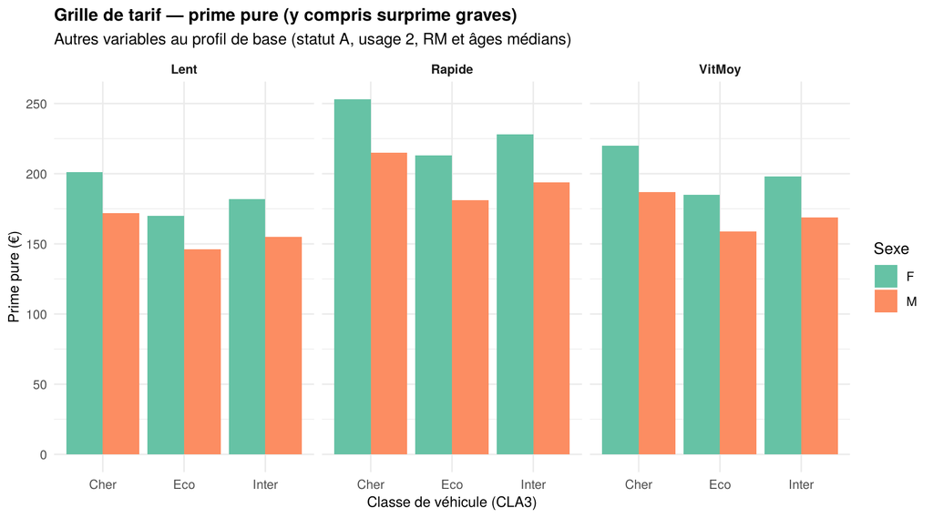

```r
ggplot(grille_aff, aes(x = CLA3, y = prime_totale, fill = SEX)) +
  geom_col(position = "dodge") +
  facet_wrap(~ VIT3, ncol = 3) +
  labs(
    title    = "Grille de tarif — prime pure (y compris surprime graves)",
    subtitle = "Autres variables au profil de base (statut A, usage 2, RM et âges médians)",
    x = "Classe de véhicule (CLA3)", y = "Prime pure (€)", fill = "Sexe"
  ) +
  scale_fill_brewer(palette = "Set2") +
  theme(strip.text = element_text(face = "bold"))
```

**Lecture :** prime pure = P(sinistre) × coût moyen conditionnel, augmentée de la surprime répartissant le coût des sinistres graves. Elle est ensuite majorée d’un **coefficient de chargement** (frais de gestion, marge, sécurité) pour obtenir la **prime commerciale**.

# 4 Synthèse

| Étape | Méthode | Résultat |
| --- | --- | --- |
| Séparation | Seuil Q99 | 1384 attritionnels / 14 graves |
| Adéquation coût | Gamma, log-normale, Weibull (MV, AIC/BIC, KS bootstrap) | Meilleur AIC : Log-normale ; KS rejette les lois testées ; GLM Gamma retenu comme hypothèse de travail |
| GLM fréquence | Binomial/logit + stepAIC | CLA3, VIT3, SEX, USAGE, K8000, RM, PERMIS, ACV — Gini test = 0.46 |
| GLM coût | Gamma/log + stepAIC | VIT3, STATUT, RM |
| Prime pure | Fréquence × coût + surprime graves | Grille tarifaire par profil |

## 4.1 Limites et pistes

- La base ne fournit pas d’exposition : la fréquence est modélisée comme la probabilité d’au moins un sinistre (binomiale) et non comme un nombre de sinistres (Poisson avec offset).
- Le seuil des sinistres graves (Q99) pourrait être affiné par une approche de valeurs extrêmes (mean excess plot, loi de Pareto généralisée).
- Variantes à tester : régression log-normale pour le coût, GLM Tweedie sur la charge totale, validation croisée k-fold.